# traineR Package

PROMiDAT

2022-04-05

The `traineR` package seeks to unify the different ways of creating predictive models and their different predictive formats. It includes methods such as K-Nearest Neighbors, Decision Trees, ADA Boosting, Extreme Gradient Boosting, Random Forest, Neural Networks, Deep Learning, Support Vector Machines, Bayesian, Linear Discriminant Analysis, Quadratic Discriminant Analysis and Logical Regression.

The main idea of the package is that all predictions can be execute using a standard syntax, also that all predictive methods can be used in the same way by default, for example, that all packages are use classification in their default invocation and all methods use a formula to determine the predictor variables (independent variables) and the response variable.

## Examples:

For the following examples we will use the `Puromycin` dataset:

| conc | rate | state |
| --- | --- | --- |
| 0.02 | 76 | treated |
| 0.02 | 47 | treated |
| 0.06 | 97 | treated |
| 0.06 | 107 | treated |
| 0.11 | 123 | treated |
| 0.11 | 139 | treated |
| 0.22 | 159 | treated |
| 0.22 | 152 | treated |
| 0.56 | 191 | treated |
| 0.56 | 201 | treated |

```r
n <- seq_len(nrow(Puromycin))
.sample <- sample(n, length(n) * 0.7)
data.train <- Puromycin[.sample,]
data.test  <- Puromycin[-.sample,]
```

### Logistic Regression

**Modeling:**

```r
model <- train.glm(state~., data.train)
model
```

```
#>
#> Call:  glm(formula = state ~ ., family = binomial, data = data.train)
#>
#> Coefficients:
#> (Intercept)         conc         rate
#>     2.79486      2.22258     -0.02771
#>
#> Degrees of Freedom: 15 Total (i.e. Null);  13 Residual
#> Null Deviance:       22.18
#> Residual Deviance: 19.8  AIC: 25.8
```

**Prediction as probability:**

**Note**: the result is always a matrix.

```r
prediction <- predict(model, data.test , type = "prob")
prediction
```

```
#>        treated untreated
#> [1,] 0.4402031 0.5597969
#> [2,] 0.5091897 0.4908103
#> [3,] 0.6926111 0.3073889
#> [4,] 0.7778385 0.2221615
#> [5,] 0.2723493 0.7276507
#> [6,] 0.4197604 0.5802396
#> [7,] 0.5379817 0.4620183
```

**Prediction as classification:**

**Note**: the result is always a factor.

```r
prediction <- predict(model, data.test , type = "class")
prediction
```

```
#> [1] untreated treated   treated   treated   untreated untreated treated
#> Levels: treated untreated
```

**Confusion Matrix**

```r
mc <- confusion.matrix(data.test, prediction)
mc
```

```
#>            prediction
#> real        treated untreated
#>   treated         3         1
#>   untreated       1         2
```

**Some Rates:**

```r
general.indexes(mc = mc)
```

```
#>
#> Confusion Matrix:
#>            prediction
#> real        treated untreated
#>   treated         3         1
#>   untreated       1         2
#>
#> Overall Accuracy: 0.7143
#> Overall Error:    0.2857
#>
#> Category Accuracy:
#>
#>       treated    untreated
#>      0.750000     0.666667
```

### ADA Boosting

**Modeling:**

```r
model <- train.ada(state~., data.train, iter = 200)
model
```

```
#> Call:
#> ada(state ~ ., data = data.train, iter = 200)
#>
#> Loss: exponential Method: discrete   Iteration: 200
#>
#> Final Confusion Matrix for Data:
#>            Final Prediction
#> True value  treated untreated
#>   treated         4         4
#>   untreated       5         3
#>
#> Train Error: 0.562
#>
#> Out-Of-Bag Error:  0.5  iteration= 6
#>
#> Additional Estimates of number of iterations:
#>
#> train.err1 train.kap1
#>          1          1
```

**Prediction as probability:**

```r
prediction <- predict(model, data.test , type = "prob")
prediction
```

```
#>      treated untreated
#> [1,]     0.5       0.5
#> [2,]     0.5       0.5
#> [3,]     0.5       0.5
#> [4,]     0.5       0.5
#> [5,]     0.5       0.5
#> [6,]     0.5       0.5
#> [7,]     0.5       0.5
```

**Prediction as classification:**

```r
prediction <- predict(model, data.test , type = "class")
prediction
```

```
#> [1] treated   untreated untreated untreated untreated untreated treated
#> Levels: treated untreated
```

**Confusion Matrix:**

```r
mc <- confusion.matrix(data.test, prediction)
mc
```

```
#>            prediction
#> real        treated untreated
#>   treated         1         3
#>   untreated       1         2
```

**Some Rates:**

```r
general.indexes(mc = mc)
```

```
#>
#> Confusion Matrix:
#>            prediction
#> real        treated untreated
#>   treated         1         3
#>   untreated       1         2
#>
#> Overall Accuracy: 0.4286
#> Overall Error:    0.5714
#>
#> Category Accuracy:
#>
#>       treated    untreated
#>      0.250000     0.666667
```

For the following examples we will use the `iris` dataset:

| Sepal.Length | Sepal.Width | Petal.Length | Petal.Width | Species |
| --- | --- | --- | --- | --- |
| 5.1 | 3.5 | 1.4 | 0.2 | setosa |
| 4.9 | 3.0 | 1.4 | 0.2 | setosa |
| 4.7 | 3.2 | 1.3 | 0.2 | setosa |
| 4.6 | 3.1 | 1.5 | 0.2 | setosa |
| 5.0 | 3.6 | 1.4 | 0.2 | setosa |
| 5.4 | 3.9 | 1.7 | 0.4 | setosa |
| 4.6 | 3.4 | 1.4 | 0.3 | setosa |
| 5.0 | 3.4 | 1.5 | 0.2 | setosa |
| 4.4 | 2.9 | 1.4 | 0.2 | setosa |
| 4.9 | 3.1 | 1.5 | 0.1 | setosa |

```r
data("iris")
n <- seq_len(nrow(iris))
.sample <- sample(n, length(n) * 0.75)
data.train <- iris[.sample,]
data.test <- iris[-.sample,]
```

### Decision Trees

**Modeling:**

```r
model <- train.rpart(Species~., data.train)
model
```

```
#> n= 112
#>
#> node), split, n, loss, yval, (yprob)
#>       * denotes terminal node
#>
#> 1) root 112 72 versicolor (0.29464286 0.35714286 0.34821429)
#>   2) Petal.Length< 2.6 33  0 setosa (1.00000000 0.00000000 0.00000000) *
#>   3) Petal.Length>=2.6 79 39 versicolor (0.00000000 0.50632911 0.49367089)
#>     6) Petal.Length< 4.85 40  2 versicolor (0.00000000 0.95000000 0.05000000) *
#>     7) Petal.Length>=4.85 39  2 virginica (0.00000000 0.05128205 0.94871795) *
```

**Prediction as probability:**

```r
prediction <- predict(model, data.test , type = "prob")
prediction
```

```
#>     setosa versicolor virginica
#> 3        1 0.00000000 0.0000000
#> 6        1 0.00000000 0.0000000
#> 8        1 0.00000000 0.0000000
#> 9        1 0.00000000 0.0000000
#> 11       1 0.00000000 0.0000000
#> 12       1 0.00000000 0.0000000
#> 16       1 0.00000000 0.0000000
#> 17       1 0.00000000 0.0000000
#> 18       1 0.00000000 0.0000000
#> 20       1 0.00000000 0.0000000
#> 21       1 0.00000000 0.0000000
#> 27       1 0.00000000 0.0000000
#> 31       1 0.00000000 0.0000000
#> 34       1 0.00000000 0.0000000
```

[output cut: 24 more lines]

**Prediction as classification:**

```r
prediction <- predict(model, data.test , type = "class")
prediction
```

```
#>  [1] setosa     setosa     setosa     setosa     setosa     setosa
#>  [7] setosa     setosa     setosa     setosa     setosa     setosa
#> [13] setosa     setosa     setosa     setosa     setosa     virginica
#> [19] versicolor versicolor versicolor virginica  versicolor versicolor
#> [25] versicolor versicolor versicolor virginica  virginica  virginica
#> [31] virginica  virginica  virginica  virginica  versicolor virginica
#> [37] virginica  virginica
#> Levels: setosa versicolor virginica
```

**Confusion Matrix:**

```r
mc <- confusion.matrix(data.test, prediction)
mc
```

```
#>             prediction
#> real         setosa versicolor virginica
#>   setosa         17          0         0
#>   versicolor      0          8         2
#>   virginica       0          1        10
```

**Some Rates:**

```r
general.indexes(mc = mc)
```

```
#>
#> Confusion Matrix:
#>             prediction
#> real         setosa versicolor virginica
#>   setosa         17          0         0
#>   versicolor      0          8         2
#>   virginica       0          1        10
#>
#> Overall Accuracy: 0.9211
#> Overall Error:    0.0789
#>
#> Category Accuracy:
#>
#>        setosa   versicolor    virginica
#>      1.000000     0.800000     0.909091
```

The model still supports the functions of the original package.

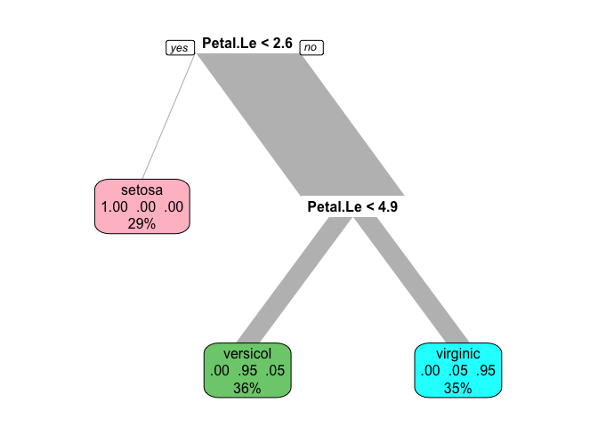

```r
library(rpart.plot)
prp(model, extra = 104, branch.type = 2,
    box.col = c("pink", "palegreen3", "cyan")[model$frame$yval])
```

### Bayesian Method

**Modeling:**

```r
model <- train.bayes(Species~., data.train)
model
```

```
#>
#> Naive Bayes Classifier for Discrete Predictors
#>
#> Call:
#> naiveBayes.default(x = X, y = Y, laplace = laplace)
#>
#> A-priori probabilities:
#> Y
#>     setosa versicolor  virginica
#>  0.2946429  0.3571429  0.3482143
#>
#> Conditional probabilities:
#>             Sepal.Length
#> Y                [,1]      [,2]
#>   setosa     4.960606 0.3472566
#>   versicolor 5.935000 0.5201331
#>   virginica  6.602564 0.6339048
#>
#>             Sepal.Width
#> Y                [,1]      [,2]
#>   setosa     3.363636 0.3586591
#>   versicolor 2.757500 0.3373255
#>   virginica  2.994872 0.3316218
#>
#>             Petal.Length
#> Y                [,1]      [,2]
#>   setosa     1.448485 0.1954501
#>   versicolor 4.245000 0.4408325
#>   virginica  5.569231 0.5587363
#>
#>             Petal.Width
#> Y                 [,1]      [,2]
#>   setosa     0.2393939 0.1143990
#>   versicolor 1.3275000 0.2087662
#>   virginica  2.0179487 0.2827234
```

**Prediction as probability:**

```r
prediction <- predict(model, data.test , type = "prob")
prediction
```

```
#>              setosa   versicolor    virginica
#>  [1,]  1.000000e+00 1.037271e-18 4.164344e-25
#>  [2,]  1.000000e+00 4.976443e-14 4.931910e-20
#>  [3,]  1.000000e+00 1.327965e-17 6.824485e-24
#>  [4,]  1.000000e+00 9.552476e-18 1.801530e-24
#>  [5,]  1.000000e+00 1.664774e-17 2.071879e-23
#>  [6,]  1.000000e+00 3.566408e-17 1.528434e-23
#>  [7,]  1.000000e+00 4.597282e-16 1.857046e-21
#>  [8,]  1.000000e+00 1.020594e-16 1.564602e-22
#>  [9,]  1.000000e+00 3.506289e-17 2.015997e-23
#> [10,]  1.000000e+00 2.749912e-17 2.472554e-23
#> [11,]  1.000000e+00 2.929050e-15 1.714519e-21
#> [12,]  1.000000e+00 1.953700e-14 5.993291e-21
#> [13,]  1.000000e+00 1.703106e-16 3.995771e-23
#> [14,]  1.000000e+00 3.658024e-19 1.400540e-24
```

[output cut: 24 more lines]

**Prediction as classification:**

```r
prediction <- predict(model, data.test , type = "class")
prediction
```

```
#>  [1] setosa     setosa     setosa     setosa     setosa     setosa
#>  [7] setosa     setosa     setosa     setosa     setosa     setosa
#> [13] setosa     setosa     setosa     setosa     setosa     virginica
#> [19] versicolor versicolor versicolor versicolor versicolor versicolor
#> [25] versicolor versicolor versicolor virginica  virginica  virginica
#> [31] virginica  virginica  virginica  virginica  virginica  virginica
#> [37] virginica  virginica
#> Levels: setosa versicolor virginica
```

**Confusion Matrix:**

```r
mc <- confusion.matrix(data.test, prediction)
mc
```

```
#>             prediction
#> real         setosa versicolor virginica
#>   setosa         17          0         0
#>   versicolor      0          9         1
#>   virginica       0          0        11
```

**Some Rates:**

```r
general.indexes(mc = mc)
```

```
#>
#> Confusion Matrix:
#>             prediction
#> real         setosa versicolor virginica
#>   setosa         17          0         0
#>   versicolor      0          9         1
#>   virginica       0          0        11
#>
#> Overall Accuracy: 0.9737
#> Overall Error:    0.0263
#>
#> Category Accuracy:
#>
#>        setosa   versicolor    virginica
#>      1.000000     0.900000     1.000000
```

### Linear Discriminant Analysis

**Modeling:**

```r
model <- train.lda(Species~., data.train)
model
```

```
#> Call:
#> lda(Species ~ ., data = data.train)
#>
#> Prior probabilities of groups:
#>     setosa versicolor  virginica
#>  0.2946429  0.3571429  0.3482143
#>
#> Group means:
#>            Sepal.Length Sepal.Width Petal.Length Petal.Width
#> setosa         4.960606    3.363636     1.448485   0.2393939
#> versicolor     5.935000    2.757500     4.245000   1.3275000
#> virginica      6.602564    2.994872     5.569231   2.0179487
#>
#> Coefficients of linear discriminants:
#>                    LD1         LD2
#> Sepal.Length  1.037875 -0.03581897
#> Sepal.Width   1.510931  2.31416896
#> Petal.Length -2.436464 -0.73575183
#> Petal.Width  -2.336288  2.36218130
#>
#> Proportion of trace:
#>    LD1    LD2
#> 0.9905 0.0095
```

**Prediction as probability:**

```r
prediction <- predict(model, data.test , type = "prob")
prediction
```

```
#>           setosa   versicolor    virginica
#> 3   1.000000e+00 4.739598e-19 2.569383e-37
#> 6   1.000000e+00 3.862882e-21 4.656143e-39
#> 8   1.000000e+00 1.110455e-19 5.350897e-38
#> 9   1.000000e+00 1.083528e-14 1.094014e-31
#> 11  1.000000e+00 1.904849e-23 7.641272e-43
#> 12  1.000000e+00 7.706275e-18 1.896661e-35
#> 16  1.000000e+00 6.564434e-28 1.013051e-47
#> 17  1.000000e+00 3.541858e-25 1.507026e-44
#> 18  1.000000e+00 5.810645e-21 1.938031e-39
#> 20  1.000000e+00 4.697332e-22 1.474857e-40
#> 21  1.000000e+00 2.514745e-19 1.315848e-37
#> 27  1.000000e+00 5.550436e-17 6.331925e-34
#> 31  1.000000e+00 9.741766e-16 5.875936e-33
#> 34  1.000000e+00 2.246415e-28 5.892962e-49
```

[output cut: 24 more lines]

**Prediction as classification:**

```r
prediction <- predict(model, data.test , type = "class")
prediction
```

```
#>  [1] setosa     setosa     setosa     setosa     setosa     setosa
#>  [7] setosa     setosa     setosa     setosa     setosa     setosa
#> [13] setosa     setosa     setosa     setosa     setosa     versicolor
#> [19] versicolor versicolor versicolor virginica  versicolor versicolor
#> [25] versicolor versicolor versicolor virginica  virginica  virginica
#> [31] virginica  virginica  virginica  virginica  virginica  virginica
#> [37] virginica  virginica
#> Levels: setosa versicolor virginica
```

**Confusion Matrix:**

```r
mc <- confusion.matrix(data.test, prediction)
mc
```

```
#>             prediction
#> real         setosa versicolor virginica
#>   setosa         17          0         0
#>   versicolor      0          9         1
#>   virginica       0          0        11
```

**Some Rates:**

```r
general.indexes(mc = mc)
```

```
#>
#> Confusion Matrix:
#>             prediction
#> real         setosa versicolor virginica
#>   setosa         17          0         0
#>   versicolor      0          9         1
#>   virginica       0          0        11
#>
#> Overall Accuracy: 0.9737
#> Overall Error:    0.0263
#>
#> Category Accuracy:
#>
#>        setosa   versicolor    virginica
#>      1.000000     0.900000     1.000000
```

### Quadratic Discriminant Analysis

**Modeling:**

```r
model <- train.qda(Species~., data.train)
model
```

```
#> Call:
#> qda(Species ~ ., data = data.train)
#>
#> Prior probabilities of groups:
#>     setosa versicolor  virginica
#>  0.2946429  0.3571429  0.3482143
#>
#> Group means:
#>            Sepal.Length Sepal.Width Petal.Length Petal.Width
#> setosa         4.960606    3.363636     1.448485   0.2393939
#> versicolor     5.935000    2.757500     4.245000   1.3275000
#> virginica      6.602564    2.994872     5.569231   2.0179487
```

**Prediction as probability:**

```r
prediction <- predict(model, data.test , type = "prob")
prediction
```

```
#>            setosa   versicolor    virginica
#> 3    1.000000e+00 7.283826e-24 1.780589e-32
#> 6    1.000000e+00 9.541669e-29 1.647842e-36
#> 8    1.000000e+00 3.398729e-25 3.867038e-34
#> 9    1.000000e+00 5.286804e-18 1.509027e-26
#> 11   1.000000e+00 5.754499e-31 3.430820e-40
#> 12   1.000000e+00 4.448181e-23 3.734149e-31
#> 16   1.000000e+00 1.081634e-40 5.074032e-47
#> 17   1.000000e+00 4.040875e-35 1.144422e-41
#> 18   1.000000e+00 1.555337e-27 6.678148e-36
#> 20   1.000000e+00 7.520922e-30 2.479910e-37
#> 21   1.000000e+00 8.323528e-24 5.437390e-34
#> 27   1.000000e+00 3.842787e-22 3.854860e-30
#> 31   1.000000e+00 1.912271e-19 1.394634e-28
#> 34   1.000000e+00 2.987053e-40 1.044789e-47
```

[output cut: 24 more lines]

**Prediction as classification:**

```r
prediction <- predict(model, data.test , type = "class")
prediction
```

```
#>  [1] setosa     setosa     setosa     setosa     setosa     setosa
#>  [7] setosa     setosa     setosa     setosa     setosa     setosa
#> [13] setosa     setosa     setosa     setosa     setosa     versicolor
#> [19] versicolor versicolor versicolor virginica  versicolor versicolor
#> [25] versicolor versicolor versicolor virginica  virginica  virginica
#> [31] virginica  virginica  virginica  virginica  virginica  virginica
#> [37] virginica  virginica
#> Levels: setosa versicolor virginica
```

**Confusion Matrix:**

```r
mc <- confusion.matrix(data.test, prediction)
mc
```

```
#>             prediction
#> real         setosa versicolor virginica
#>   setosa         17          0         0
#>   versicolor      0          9         1
#>   virginica       0          0        11
```

**Some Rates:**

```r
general.indexes(mc = mc)
```

```
#>
#> Confusion Matrix:
#>             prediction
#> real         setosa versicolor virginica
#>   setosa         17          0         0
#>   versicolor      0          9         1
#>   virginica       0          0        11
#>
#> Overall Accuracy: 0.9737
#> Overall Error:    0.0263
#>
#> Category Accuracy:
#>
#>        setosa   versicolor    virginica
#>      1.000000     0.900000     1.000000
```

### Random Forest

**Modeling:**

```r
model <- train.randomForest(Species~., data.train)
model
```

```
#>
#> Call:
#>  randomForest(formula = Species ~ ., data = data.train, importance = TRUE)
#>                Type of random forest: classification
#>                      Number of trees: 500
#> No. of variables tried at each split: 2
#>
#>         OOB estimate of  error rate: 5.36%
#> Confusion matrix:
#>            setosa versicolor virginica class.error
#> setosa         33          0         0  0.00000000
#> versicolor      0         37         3  0.07500000
#> virginica       0          3        36  0.07692308
```

**Prediction as probability:**

```r
prediction <- predict(model, data.test , type = "prob")
prediction
```

```
#>     setosa versicolor virginica
#> 3    1.000      0.000     0.000
#> 6    0.998      0.002     0.000
#> 8    1.000      0.000     0.000
#> 9    0.994      0.004     0.002
#> 11   0.996      0.004     0.000
#> 12   1.000      0.000     0.000
#> 16   0.984      0.016     0.000
#> 17   0.998      0.002     0.000
#> 18   1.000      0.000     0.000
#> 20   1.000      0.000     0.000
#> 21   0.974      0.026     0.000
#> 27   1.000      0.000     0.000
#> 31   1.000      0.000     0.000
#> 34   0.988      0.012     0.000
```

[output cut: 24 more lines]

**Prediction as classification:**

```r
prediction <- predict(model, data.test , type = "class")
prediction
```

```
#>  [1] setosa     setosa     setosa     setosa     setosa     setosa
#>  [7] setosa     setosa     setosa     setosa     setosa     setosa
#> [13] setosa     setosa     setosa     setosa     setosa     versicolor
#> [19] versicolor versicolor versicolor virginica  versicolor versicolor
#> [25] versicolor versicolor versicolor virginica  virginica  virginica
#> [31] virginica  virginica  virginica  virginica  virginica  virginica
#> [37] virginica  virginica
#> Levels: setosa versicolor virginica
```

**Confusion Matrix:**

```r
mc <- confusion.matrix(data.test, prediction)
mc
```

```
#>             prediction
#> real         setosa versicolor virginica
#>   setosa         17          0         0
#>   versicolor      0          9         1
#>   virginica       0          0        11
```

**Some Rates:**

```r
general.indexes(mc = mc)
```

```
#>
#> Confusion Matrix:
#>             prediction
#> real         setosa versicolor virginica
#>   setosa         17          0         0
#>   versicolor      0          9         1
#>   virginica       0          0        11
#>
#> Overall Accuracy: 0.9737
#> Overall Error:    0.0263
#>
#> Category Accuracy:
#>
#>        setosa   versicolor    virginica
#>      1.000000     0.900000     1.000000
```

The model still supports the functions of the original package.

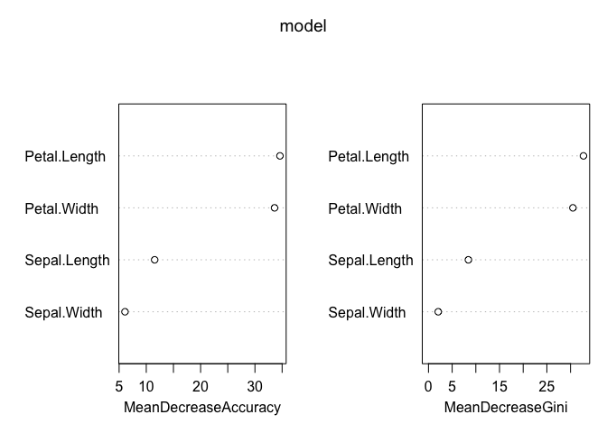

```r
library(randomForest)
varImpPlot(model)
```

### K-Nearest Neighbors

**Modeling:**

```r
model <- train.knn(Species~., data.train)
model
```

```
#>
#> Call:
#> kknn::train.kknn(formula = Species ~ ., data = data.train)
#>
#> Type of response variable: nominal
#> Minimal misclassification: 0.05357143
#> Best kernel: optimal
#> Best k: 8
```

**Prediction as probability:**

```r
prediction <- predict(model, data.test , type = "prob")
prediction
```

```
#>       setosa versicolor virginica
#>  [1,]      1 0.00000000 0.0000000
#>  [2,]      1 0.00000000 0.0000000
#>  [3,]      1 0.00000000 0.0000000
#>  [4,]      1 0.00000000 0.0000000
#>  [5,]      1 0.00000000 0.0000000
#>  [6,]      1 0.00000000 0.0000000
#>  [7,]      1 0.00000000 0.0000000
#>  [8,]      1 0.00000000 0.0000000
#>  [9,]      1 0.00000000 0.0000000
#> [10,]      1 0.00000000 0.0000000
#> [11,]      1 0.00000000 0.0000000
#> [12,]      1 0.00000000 0.0000000
#> [13,]      1 0.00000000 0.0000000
#> [14,]      1 0.00000000 0.0000000
```

[output cut: 24 more lines]

**Prediction as classification:**

```r
prediction <- predict(model, data.test , type = "class")
prediction
```

```
#>  [1] setosa     setosa     setosa     setosa     setosa     setosa
#>  [7] setosa     setosa     setosa     setosa     setosa     setosa
#> [13] setosa     setosa     setosa     setosa     setosa     versicolor
#> [19] versicolor versicolor versicolor virginica  versicolor versicolor
#> [25] versicolor versicolor versicolor virginica  virginica  virginica
#> [31] virginica  virginica  virginica  virginica  virginica  virginica
#> [37] virginica  virginica
#> Levels: setosa versicolor virginica
```

**Confusion Matrix:**

```r
mc <- confusion.matrix(data.test, prediction)
mc
```

```
#>             prediction
#> real         setosa versicolor virginica
#>   setosa         17          0         0
#>   versicolor      0          9         1
#>   virginica       0          0        11
```

**Some Rates:**

```r
general.indexes(mc = mc)
```

```
#>
#> Confusion Matrix:
#>             prediction
#> real         setosa versicolor virginica
#>   setosa         17          0         0
#>   versicolor      0          9         1
#>   virginica       0          0        11
#>
#> Overall Accuracy: 0.9737
#> Overall Error:    0.0263
#>
#> Category Accuracy:
#>
#>        setosa   versicolor    virginica
#>      1.000000     0.900000     1.000000
```

### Neural Networks (nnet)

**Modeling:**

```r
model <- train.nnet(Species~., data.train, size = 20)
model
```

```
#> a 4-20-3 network with 163 weights
#> inputs: Sepal.Length Sepal.Width Petal.Length Petal.Width
#> output(s): Species
#> options were - softmax modelling
```

**Prediction as probability:**

```r
prediction <- predict(model, data.test , type = "prob")
prediction
```

```
#>           setosa   versicolor    virginica
#> 3   1.000000e+00 9.445818e-12 3.043049e-27
#> 6   1.000000e+00 8.733221e-12 3.944353e-27
#> 8   1.000000e+00 9.469569e-12 3.656317e-27
#> 9   1.000000e+00 1.163167e-11 3.840243e-27
#> 11  1.000000e+00 8.818073e-12 3.498297e-27
#> 12  1.000000e+00 9.628105e-12 3.948991e-27
#> 16  1.000000e+00 8.259265e-12 3.610398e-27
#> 17  1.000000e+00 8.232772e-12 3.078802e-27
#> 18  1.000000e+00 8.921348e-12 3.352714e-27
#> 20  1.000000e+00 8.600326e-12 3.593398e-27
#> 21  1.000000e+00 1.026156e-11 4.211786e-27
#> 27  1.000000e+00 9.555198e-12 4.005126e-27
#> 31  1.000000e+00 1.136378e-11 4.333767e-27
#> 34  1.000000e+00 8.194106e-12 3.254558e-27
```

[output cut: 24 more lines]

**Prediction as classification:**

```r
prediction <- predict(model, data.test , type = "class")
prediction
```

```
#>  [1] setosa     setosa     setosa     setosa     setosa     setosa
#>  [7] setosa     setosa     setosa     setosa     setosa     setosa
#> [13] setosa     setosa     setosa     setosa     setosa     versicolor
#> [19] versicolor versicolor versicolor virginica  versicolor versicolor
#> [25] versicolor versicolor versicolor virginica  virginica  virginica
#> [31] virginica  virginica  virginica  virginica  versicolor virginica
#> [37] virginica  virginica
#> Levels: setosa versicolor virginica
```

**Confusion Matrix:**

```r
mc <- confusion.matrix(data.test, prediction)
mc
```

```
#>             prediction
#> real         setosa versicolor virginica
#>   setosa         17          0         0
#>   versicolor      0          9         1
#>   virginica       0          1        10
```

**Some Rates:**

```r
general.indexes(mc = mc)
```

```
#>
#> Confusion Matrix:
#>             prediction
#> real         setosa versicolor virginica
#>   setosa         17          0         0
#>   versicolor      0          9         1
#>   virginica       0          1        10
#>
#> Overall Accuracy: 0.9474
#> Overall Error:    0.0526
#>
#> Category Accuracy:
#>
#>        setosa   versicolor    virginica
#>      1.000000     0.900000     0.909091
```

### Neural Networks (neuralnet)

**Modeling:**

```r
model <- train.neuralnet(Species~., data.train, hidden = c(5, 7, 6),
                         linear.output = FALSE, threshold = 0.01, stepmax = 1e+06)
summary(model)
```

```
#>                     Length Class      Mode
#> call                  7    -none-     call
#> response            336    -none-     logical
#> covariate           448    -none-     numeric
#> model.list            2    -none-     list
#> err.fct               1    -none-     function
#> act.fct               1    -none-     function
#> linear.output         1    -none-     logical
#> data                  5    data.frame list
#> exclude               0    -none-     NULL
#> net.result            1    -none-     list
#> weights               1    -none-     list
#> generalized.weights   1    -none-     list
#> startweights          1    -none-     list
#> result.matrix       139    -none-     numeric
#> prmdt                 4    -none-     list
```

**Prediction as probability:**

```r
prediction <- predict(model, data.test , type = "prob")
prediction
```

```
#>           setosa   versicolor    virginica
#> 3   1.000000e+00 1.285066e-03 1.044123e-08
#> 6   1.000000e+00 1.280897e-03 1.047568e-08
#> 8   1.000000e+00 1.283393e-03 1.044414e-08
#> 9   1.000000e+00 1.259949e-03 1.057419e-08
#> 11  1.000000e+00 1.305484e-03 1.032710e-08
#> 12  1.000000e+00 1.269736e-03 1.052630e-08
#> 16  1.000000e+00 1.327859e-03 1.025500e-08
#> 17  1.000000e+00 1.319906e-03 1.028125e-08
#> 18  1.000000e+00 1.292498e-03 1.040400e-08
#> 20  1.000000e+00 1.292348e-03 1.042200e-08
#> 21  1.000000e+00 1.273429e-03 1.047926e-08
#> 27  1.000000e+00 1.262960e-03 1.056551e-08
#> 31  1.000000e+00 1.260675e-03 1.056026e-08
#> 34  1.000000e+00 1.343136e-03 1.016778e-08
```

[output cut: 24 more lines]

**Prediction as classification:**

```r
prediction <- predict(model, data.test , type = "class")
prediction
```

```
#>  [1] setosa     setosa     setosa     setosa     setosa     setosa
#>  [7] setosa     setosa     setosa     setosa     setosa     setosa
#> [13] setosa     setosa     setosa     setosa     setosa     versicolor
#> [19] versicolor versicolor versicolor virginica  versicolor versicolor
#> [25] versicolor versicolor versicolor virginica  virginica  virginica
#> [31] virginica  virginica  virginica  virginica  virginica  virginica
#> [37] virginica  virginica
#> Levels: setosa versicolor virginica
```

**Confusion Matrix:**

```r
mc <- confusion.matrix(data.test, prediction)
mc
```

```
#>             prediction
#> real         setosa versicolor virginica
#>   setosa         17          0         0
#>   versicolor      0          9         1
#>   virginica       0          0        11
```

**Some Rates:**

```r
general.indexes(mc = mc)
```

```
#>
#> Confusion Matrix:
#>             prediction
#> real         setosa versicolor virginica
#>   setosa         17          0         0
#>   versicolor      0          9         1
#>   virginica       0          0        11
#>
#> Overall Accuracy: 0.9737
#> Overall Error:    0.0263
#>
#> Category Accuracy:
#>
#>        setosa   versicolor    virginica
#>      1.000000     0.900000     1.000000
```

### Support Vector Machines

**Modeling:**

```r
model <- train.svm(Species~., data.train)
model
```

```
#>
#> Call:
#> svm(formula = Species ~ ., data = data.train, probability = TRUE)
#>
#>
#> Parameters:
#>    SVM-Type:  C-classification
#>  SVM-Kernel:  radial
#>        cost:  1
#>
#> Number of Support Vectors:  47
```

**Prediction as probability:**

```r
prediction <- predict(model, data.test , type = "prob")
prediction
```

```
#>          setosa  versicolor   virginica
#> 3   0.964592066 0.020095251 0.015312683
#> 6   0.956900077 0.025918059 0.017181864
#> 8   0.970170861 0.016654699 0.013174440
#> 9   0.945849964 0.034958295 0.019191741
#> 11  0.969049746 0.018322508 0.012627746
#> 12  0.966375575 0.018852671 0.014771754
#> 16  0.843698151 0.077904894 0.078396955
#> 17  0.959405448 0.023353019 0.017241533
#> 18  0.970884316 0.016663763 0.012451921
#> 20  0.965069285 0.019659062 0.015271654
#> 21  0.962770438 0.021768064 0.015461499
#> 27  0.965357749 0.020753195 0.013889056
#> 31  0.960712206 0.024142089 0.015145705
#> 34  0.926014849 0.038738392 0.035246759
```

[output cut: 24 more lines]

**Prediction as classification:**

```r
prediction <- predict(model, data.test , type = "class")
prediction
```

```
#>  [1] setosa     setosa     setosa     setosa     setosa     setosa
#>  [7] setosa     setosa     setosa     setosa     setosa     setosa
#> [13] setosa     setosa     setosa     setosa     setosa     versicolor
#> [19] versicolor versicolor versicolor virginica  versicolor versicolor
#> [25] versicolor versicolor versicolor virginica  virginica  virginica
#> [31] virginica  virginica  virginica  virginica  virginica  virginica
#> [37] virginica  virginica
#> Levels: setosa versicolor virginica
```

**Confusion Matrix:**

```r
mc <- confusion.matrix(data.test, prediction)
mc
```

```
#>             prediction
#> real         setosa versicolor virginica
#>   setosa         17          0         0
#>   versicolor      0          9         1
#>   virginica       0          0        11
```

**Some Rates:**

```r
general.indexes(mc = mc)
```

```
#>
#> Confusion Matrix:
#>             prediction
#> real         setosa versicolor virginica
#>   setosa         17          0         0
#>   versicolor      0          9         1
#>   virginica       0          0        11
#>
#> Overall Accuracy: 0.9737
#> Overall Error:    0.0263
#>
#> Category Accuracy:
#>
#>        setosa   versicolor    virginica
#>      1.000000     0.900000     1.000000
```

### Extreme Gradient Boosting

**Modeling:**

```r
model <- train.xgboost(Species~., data.train, nrounds = 79, maximize = FALSE, verbose = 0)
model
```

```
#> ##### xgb.Booster
#> raw: 141 Kb
#> call:
#>   xgb.train(params = params, data = train_aux, nrounds = nrounds,
#>     watchlist = watchlist, obj = obj, feval = feval, verbose = verbose,
#>     print_every_n = print_every_n, early_stopping_rounds = early_stopping_rounds,
#>     maximize = maximize, save_period = save_period, save_name = save_name,
#>     xgb_model = xgb_model, callbacks = callbacks, eval_metric = "mlogloss")
#> params (as set within xgb.train):
#>   booster = "gbtree", objective = "multi:softprob", eta = "0.3", gamma = "0", max_depth = "6", min_child_weight = "1", subsample = "1", colsample_bytree = "1", num_class = "3", eval_metric = "mlogloss", validate_parameters = "TRUE"
#> xgb.attributes:
#>   niter
#> callbacks:
#>   cb.evaluation.log()
#> # of features: 4
#> niter: 79
#> nfeatures : 4
#> evaluation_log:
#>     iter train_mlogloss
#>        1       0.745818
#>        2       0.532089
#> ---
#>       78       0.016986
#>       79       0.016926
```

**Prediction as probability:**

```r
prediction <- predict(model, data.test , type = "prob")
prediction
```

```
#>             setosa  versicolor   virginica
#>  [1,] 0.9937896132 0.004962827 0.001247580
#>  [2,] 0.9893139005 0.009444213 0.001241961
#>  [3,] 0.9937896132 0.004962827 0.001247580
#>  [4,] 0.9917478561 0.006653214 0.001598984
#>  [5,] 0.9893139005 0.009444213 0.001241961
#>  [6,] 0.9937896132 0.004962827 0.001247580
#>  [7,] 0.9784784317 0.020293176 0.001228359
#>  [8,] 0.9893139005 0.009444213 0.001241961
#>  [9,] 0.9937896132 0.004962827 0.001247580
#> [10,] 0.9937896132 0.004962827 0.001247580
#> [11,] 0.9893139005 0.009444213 0.001241961
#> [12,] 0.9937896132 0.004962827 0.001247580
#> [13,] 0.9937896132 0.004962827 0.001247580
#> [14,] 0.9832919240 0.015473676 0.001234402
```

[output cut: 24 more lines]

**Prediction as classification:**

```r
prediction <- predict(model, data.test , type = "class")
prediction
```

```
#>  [1] setosa     setosa     setosa     setosa     setosa     setosa
#>  [7] setosa     setosa     setosa     setosa     setosa     setosa
#> [13] setosa     setosa     setosa     setosa     setosa     versicolor
#> [19] versicolor versicolor versicolor virginica  versicolor versicolor
#> [25] versicolor versicolor versicolor virginica  virginica  virginica
#> [31] virginica  virginica  virginica  virginica  virginica  virginica
#> [37] virginica  virginica
#> Levels: setosa versicolor virginica
```

**Confusion Matrix:**

```r
mc <- confusion.matrix(data.test, prediction)
mc
```

```
#>             prediction
#> real         setosa versicolor virginica
#>   setosa         17          0         0
#>   versicolor      0          9         1
#>   virginica       0          0        11
```

**Some Rates:**

```r
general.indexes(mc = mc)
```

```
#>
#> Confusion Matrix:
#>             prediction
#> real         setosa versicolor virginica
#>   setosa         17          0         0
#>   versicolor      0          9         1
#>   virginica       0          0        11
#>
#> Overall Accuracy: 0.9737
#> Overall Error:    0.0263
#>
#> Category Accuracy:
#>
#>        setosa   versicolor    virginica
#>      1.000000     0.900000     1.000000
```